# James Skane - Assignment 9

```r
library('ggplot2')
library('dplyr')
library('plyr')
library('corrgram')
#install.packages("irr")
library('irr')
#install.packages("survminer")
library("survival")
library("survminer")
setwd('/Users/desert/hs616')
```

#### *1. Read in the data for the 664 matched pairs: bioprosthetics_match.csv contains patients with bioprosthetic valves and mechprosthetics_match.csv contains the patients with mechanical valves. These patients are matched with the patient in in the corresponding row of the other data set (ie: row 1 of bioprosthetics_match matches row 1 of mechprosthetics_match, etc.)*

```r
new_mechprosthetics <- read.table(file="mechprosthetics_death_match.csv", sep =",", header = TRUE)
new_bioprosthetics <- read.table(file="bioprosthetics_death_match.csv", sep =",", header = TRUE)
df<-bind_rows(new_bioprosthetics,new_mechprosthetics)
```

#### *2. Create side-by-side plots of the distributions of age, sex, race, cancer status and emergency room admission status jn the 2 datasets. In your report comment on the quality of the matching.*

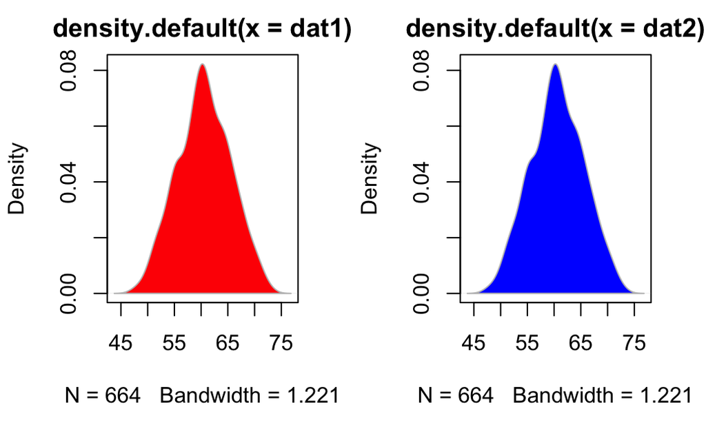

```r
plot_compare <- function(dat1, dat2){
  par(mfrow=c(1, 2))
  d1 <- density(dat1)
  d2 <- density(dat2)
  plot(d1, type="n")
  polygon(d1, col="red", border="gray")
  plot(d2, type="n")
  polygon(d2, col="blue", border="gray")

}
plot_compare(new_bioprosthetics$age, new_mechprosthetics$age)
```

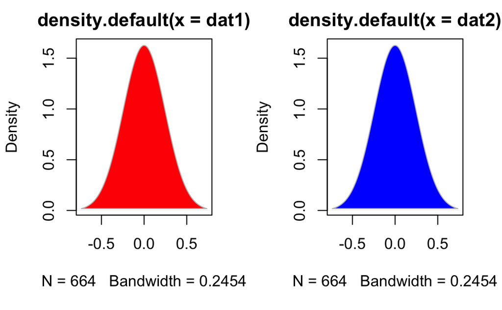

```r
new_bioprosthetics$sex <- ifelse(new_bioprosthetics$sex=='male', 1, 0)
new_mechprosthetics$sex <- ifelse(new_mechprosthetics$sex=='male', 1, 0)
plot_compare(new_bioprosthetics$sex, new_mechprosthetics$sex)
```

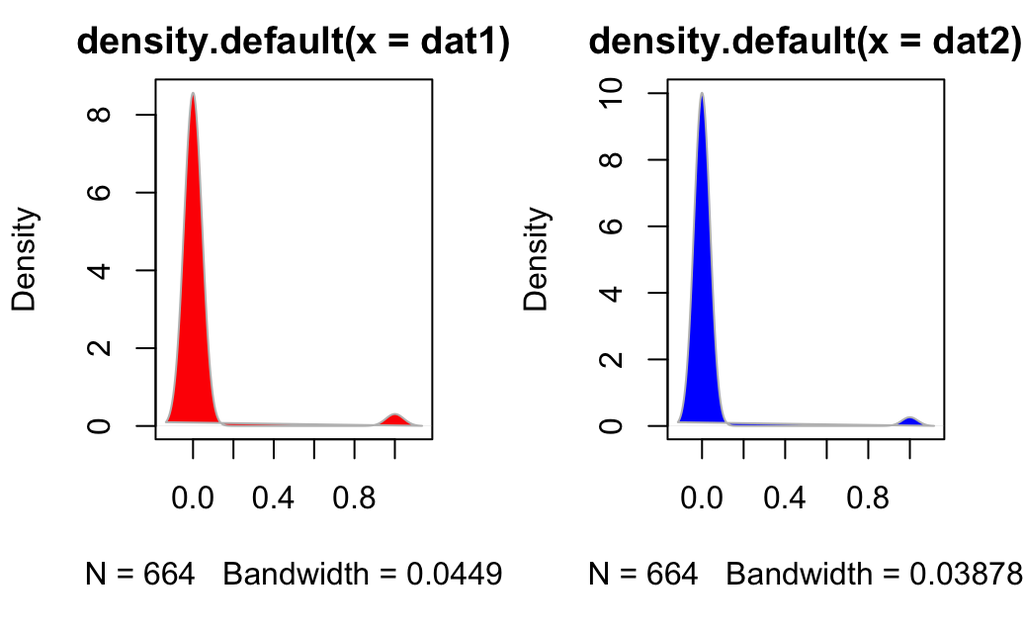

```r
plot_compare(new_bioprosthetics$cancer, new_mechprosthetics$cancer)
```

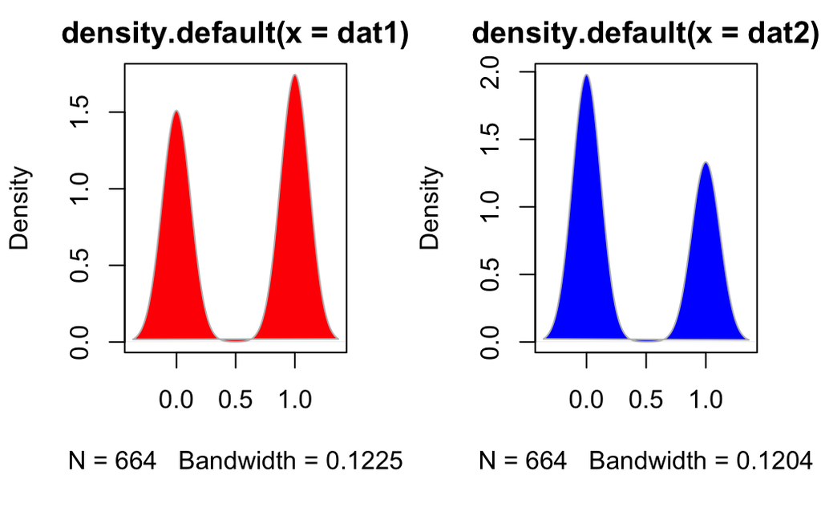

```r
plot_compare(new_bioprosthetics$emergent_admission,
             new_mechprosthetics$emergent_admission)
```